# 2_forecasting_model_eu slides

### 2. Выбор модели для прогнозирования ВВП ЕС

### Проверка

- [RMSFE](https://otexts.com/fpp2/accuracy.html)
- [Methods used in M3](https://www.sciencedirect.com/science/article/pii/S0169207006000239)
- [Regression and time series model selection in small samples](https://www.stat.berkeley.edu/~binyu/summer08/Hurvich.AICc.pdf): KL information

10% наблюдений

- rus: прогноз на 1/2
- eu/us: прогноз на 4/8
- eu - каждое 4, зависимость точности вычислений и метода для рядов разной длины?

```r
library(forecast)
library(ggplot2)
library(dplyr)
```

## Aggregated TS

```r
gdp_agg <- read.csv(file="data/eu_gdp_eu28.csv", header=TRUE, sep=",")
```

```r
gdp_agg  <- ts(gdp_agg$values, frequency = 4, start = 1995)
gdp_agg
```

```
        Qtr1    Qtr2    Qtr3    Qtr4
1995 1600924 1640884 1652305 1743835
1996 1670650 1734794 1739728 1838490
1997 1749619 1835861 1843307 1942571
1998 1858776 1916809 1916750 2007456
1999 1916239 1994164 2004996 2136135
2000 2080875 2147249 2152786 2276357
2001 2178405 2256855 2240603 2362453
2002 2268981 2335413 2328132 2440410
2003 2310342 2351052 2365793 2483607
2004 2399035 2492690 2483479 2600491
2005 2488651 2602248 2585346 2724579
2006 2635084 2722285 2734180 2884522
2007 2815036 2890300 2900078 3029662
2008 2890348 2967930 2939059 2956481
2009 2690720 2765335 2778804 2883050
2010 2754388 2875238 2887422 3008364
2011 2891787 2957860 2940656 3046158
2012 2932008 3009640 3024573 3111426
2013 2944531 3035107 3040628 3156913
2014 3039096 3130049 3156642 3272369
2015 3192324 3308214 3322218 3448333
2016 3265629 3368178 3312360 3431287
2017 3325036 3430170 3423832 3563620
2018 3434383 3538041 3533647
```

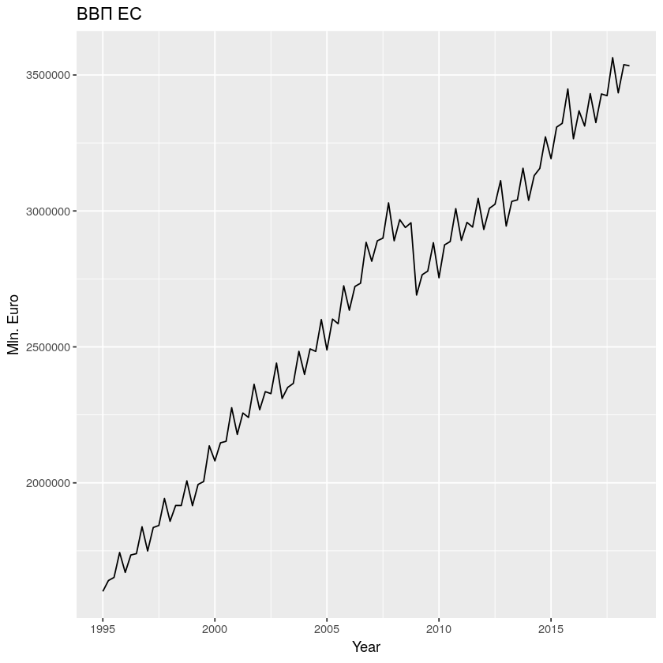

```r
autoplot(gdp_agg) +
    xlab("Year") + ylab("Mln. Euro") +
    ggtitle("ВВП ЕС")
```

```r
train <- window(gdp_agg, end=c(2016,4))
test <- window(gdp_agg, start=c(2017,1))
```

#### Модель 0: RW with drift

The random walk with drift model is

$$Y_t=c + Y_{t-1} + Z_t$$

`rwf(y, h, drift=TRUE)`

#### Модель 1: Theta

`library(foreast)`

Equivalent to simple exponential smoothing with drift

$\sim$ ETS(AAdN)

```r
auto.arima(train, ic='bic')
```

```
Series: train
ARIMA(2,0,0)(0,1,1)[4] with drift

Coefficients:
         ar1      ar2     sma1      drift
      1.2732  -0.3656  -0.7027  19587.833
s.e.  0.1012   0.1046   0.0977   2584.694

sigma^2 estimated as 832901686:  log likelihood=-981.91
AIC=1973.82   AICc=1974.59   BIC=1985.97
```

```r
Arima(train, order=c(2,1,2), seasonal=c(2,1,2))
```

```
Series: train
ARIMA(2,1,2)(2,1,2)[4]

Coefficients:
          ar1     ar2     ma1      ma2    sar1     sar2     sma1    sma2
      -0.5717  0.4272  0.9164  -0.0690  0.1167  -0.3430  -0.7947  0.0709
s.e.   0.2334  0.2336  0.2504   0.2483  0.3190   0.1422   0.3319  0.3003

sigma^2 estimated as 8.02e+08:  log likelihood=-967.46
AIC=1952.92   AICc=1955.39   BIC=1974.69
```

```r
gdp_rwf <- rwf(train,h=7)
gdp_rwfwd <- rwf(train,h=7, drift=TRUE)
gdp_snaive  <- snaive(train,h=7)
gdp_theta  <- thetaf(train, h=7)
gdp_arima  <- forecast(auto.arima(train), h=7)
gdp_ets <- forecast(ets(train), h=7)
```

```r
accuracy(gdp_rwf, test)
accuracy(gdp_rwfwd, test)
accuracy(gdp_snaive, test)
accuracy(gdp_theta, test)
accuracy(gdp_arima, test)
accuracy(gdp_ets, test)
```

|  | ME | RMSE | MAE | MPE | MAPE | MASE | ACF1 | Theil's U |
| --- | --- | --- | --- | --- | --- | --- | --- | --- |
| Training set | 21038.66 | 93246.38 | 79262.43 | 0.8102572 | 3.103855 | 0.8108200 | -0.66298186 | NA |
| Test set | 32817.03 | 85139.78 | 65623.51 | 0.8959751 | 1.880483 | 0.6712998 | 0.04778851 | 0.8211688 |

|  | ME | RMSE | MAE | MPE | MAPE | MASE | ACF1 | Theil's U |
| --- | --- | --- | --- | --- | --- | --- | --- | --- |
| Training set | 8.563869e-11 | 90841.96 | 75477.66 | -0.04039074 | 2.964913 | 0.7721034 | -0.6629819 | NA |
| Test set | -5.133762e+04 | 73862.83 | 65102.72 | -1.51299717 | 1.899265 | 0.6659724 | -0.4636484 | 0.6069265 |

|  | ME | RMSE | MAE | MPE | MAPE | MASE | ACF1 | Theil's U |
| --- | --- | --- | --- | --- | --- | --- | --- | --- |
| Training set | 80232.22 | 107828.1 | 97755.89 | 3.245085 | 3.871968 | 1.00000 | 0.8540931 | NA |
| Test set | 132158.14 | 143232.6 | 132158.14 | 3.791442 | 3.791442 | 1.35192 | 0.5292738 | 1.532192 |

|  | ME | RMSE | MAE | MPE | MAPE | MASE | ACF1 | Theil's U |
| --- | --- | --- | --- | --- | --- | --- | --- | --- |
| Training set | 18286.59 | 34795.17 | 27222.9 | 0.7390613 | 1.104826 | 0.2784784 | 0.3027664 | NA |
| Test set | 105149.04 | 110592.60 | 105149.0 | 3.0218262 | 3.021826 | 1.0756287 | 0.5889082 | 1.176769 |

|  | ME | RMSE | MAE | MPE | MAPE | MASE | ACF1 | Theil's U |
| --- | --- | --- | --- | --- | --- | --- | --- | --- |
| Training set | 496.5713 | 27093.45 | 18745.11 | 0.04021781 | 0.7075616 | 0.1917542 | -0.006078177 | NA |
| Test set | 53108.4852 | 54480.16 | 53108.49 | 1.52742685 | 1.5274268 | 0.5432766 | 0.574894662 | 0.5760742 |

|  | ME | RMSE | MAE | MPE | MAPE | MASE | ACF1 | Theil's U |
| --- | --- | --- | --- | --- | --- | --- | --- | --- |
| Training set | -1002.636 | 28131.63 | 19893.79 | -0.03510539 | 0.7573732 | 0.2035047 | 0.2537223 | NA |
| Test set | 93065.844 | 97402.36 | 93065.84 | 2.67558565 | 2.6755857 | 0.9520229 | 0.5815305 | 1.034584 |

```r
fasster_check  <- c(3292156.27766825, 3353171.90608297, 3334572.86348444, 3426196.61574518, 3293225.27365395, 3354240.90206867, 3335641.85947014)
```

```r
accuracy(fasster_check, test)
```

|  | ME | RMSE | MAE | MPE | MAPE | ACF1 | Theil's U |
| --- | --- | --- | --- | --- | --- | --- | --- |
| Test set | 122789 | 134576.6 | 122789 | 3.515055 | 3.515055 | 0.524589 | 1.45646 |

```r
accuracy(ts(fasster_check, frequency = 4, start = 2017), test)
```

|  | ME | RMSE | MAE | MPE | MAPE | ACF1 | Theil's U |
| --- | --- | --- | --- | --- | --- | --- | --- |
| Test set | 122789 | 134576.6 | 122789 | 3.515055 | 3.515055 | 0.524589 | 1.45646 |

#### fasster

https://mitchelloharawild.com/melburn17/#74

Special DLM components can be specified using special functions defined below:

- `seas(s)`: Creates seasonal factors with seasonality s
- `trig(s)`: Creates seasonal fourier terms with seasonality s
- `poly(n)`: Creates a polynomial of order n (poly(1) creates a level, poly(2) creates a trend)
- `ARMA(ar, ma)`: Creates ARMA terms with coefficient vectors ar and ma
- `custom(dlm)`: Creates a custom dlm structure, using dlm

The model parameters are estimated using the following heuristic:

- Filter the data using the specified model with non-zero state variances
- Obtain smoothed states $(θ^{(s)}t=θ_t|D_T)$ to approximate correct behaviour
- The initial state parameters taken from the first smoothed state: $m_0=E(θ^{(s)}_0), C_0=Var(θ^{(s)}_0)$
- Obtain state noise variances from the smoothed variance of $w_t: W=Var(w^{(s)}_t)=Var(θ^{(s)}_t−Gθ^{(s)}_{t−1}) $
- Obtain measurement noise variance from smoothed variance of $v_t: V=Var(v^{(s)}_t)=Var(y_t−F_tθ^{(s)}_t)$
- Repair restricted state variances for seasonal factors and ARMA terms

```r
library(fasster)
```

```r
train_in_diff = train %>%
  as_tsibble %>% mutate(d_value = value - lag(value)) %>% filter(index >= "2010-01-01")
fit = train %>% as_tsibble() %>%
  model(fasster = FASSTER(value ~ poly(2) + trig(4)))
fit_in_diff = train_in_diff %>%
  model(fasster = FASSTER(d_value ~ poly(1) + trig(4)))

fit %>% summary
```

```
           Length Class  Mode
dlm         10    dlm    list
dlm_future  10    dlm    list
est          4    tbl_ts list
states     440    -none- numeric
```

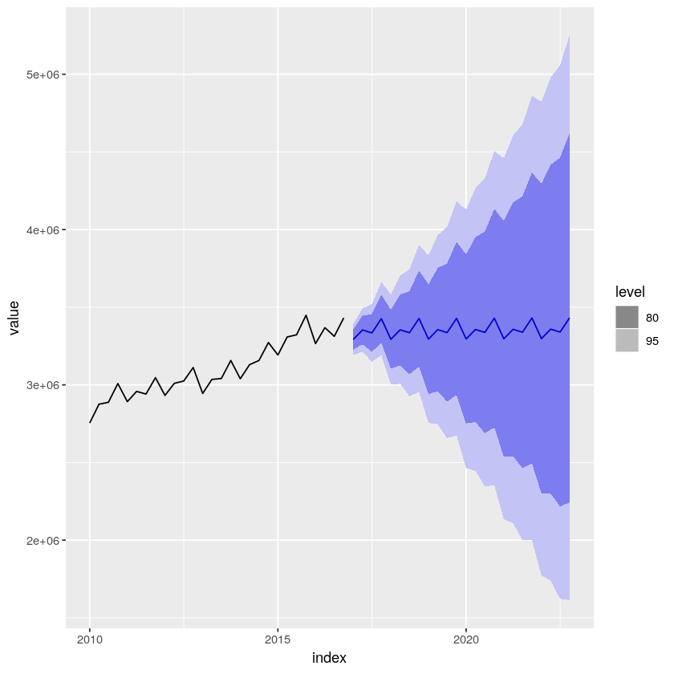

```r
gdp_fasster_in_diff  <- fit_in_diff %>%
  forecast(h=24)
gdp_fasster  <- fit %>%
  forecast(h=24)

autoplot(gdp_fasster, train_in_diff)
```

```r
head(train_in_diff)
```

[output not shown]

```r
fit %>% components()
```

| .model | index | value | poly(2) | trig(4) |
| --- | --- | --- | --- | --- |
| fasster | 1995 Q1 | 1600924 | 1646999 | -58967.265 |
| fasster | 1995 Q2 | 1640884 | 1653828 | 1781.115 |
| fasster | 1995 Q3 | 1652305 | 1652948 | -17085.177 |
| fasster | 1995 Q4 | 1743835 | 1671531 | 74271.327 |
| fasster | 1996 Q1 | 1670650 | 1678540 | -58967.265 |
| fasster | 1996 Q2 | 1734794 | 1737917 | 1781.115 |
| fasster | 1996 Q3 | 1739728 | 1758294 | -17085.177 |
| fasster | 1996 Q4 | 1838490 | 1780452 | 74271.326 |
| fasster | 1997 Q1 | 1749619 | 1787164 | -58967.265 |
| fasster | 1997 Q2 | 1835861 | 1826490 | 1781.115 |
| fasster | 1997 Q3 | 1843307 | 1859102 | -17085.177 |
| fasster | 1997 Q4 | 1942571 | 1887916 | 74271.326 |
| fasster | 1998 Q1 | 1858776 | 1895985 | -58967.265 |
| fasster | 1998 Q2 | 1916809 | 1939295 | 1781.115 |
| fasster | 1998 Q3 | 1916750 | 1943381 | -17085.177 |
| fasster | 1998 Q4 | 2007456 | 1954115 | 74271.326 |
| fasster | 1999 Q1 | 1916239 | 1950060 | -58967.265 |
| fasster | 1999 Q2 | 1994164 | 1985563 | 1781.115 |
| fasster | 1999 Q3 | 2004996 | 2011064 | -17085.177 |
| fasster | 1999 Q4 | 2136135 | 2043143 | 74271.326 |
| fasster | 2000 Q1 | 2080875 | 2086782 | -58967.265 |
| fasster | 2000 Q2 | 2147249 | 2171598 | 1781.115 |
| fasster | 2000 Q3 | 2152786 | 2194249 | -17085.177 |
| fasster | 2000 Q4 | 2276357 | 2209772 | 74271.326 |
| fasster | 2001 Q1 | 2178405 | 2233902 | -58967.265 |
| fasster | 2001 Q2 | 2256855 | 2266718 | 1781.115 |
| fasster | 2001 Q3 | 2240603 | 2285401 | -17085.177 |
| fasster | 2001 Q4 | 2362453 | 2283833 | 74271.326 |
| fasster | 2002 Q1 | 2268981 | 2305310 | -58967.265 |
| fasster | 2002 Q2 | 2335413 | 2346803 | 1781.115 |
| ⋮ | ⋮ | ⋮ | ⋮ | ⋮ |
| fasster | 2009 Q3 | 2778804 | 2692179 | -17085.177 |
| fasster | 2009 Q4 | 2883050 | 2739470 | 74271.326 |
| fasster | 2010 Q1 | 2754388 | 2787241 | -58967.265 |
| fasster | 2010 Q2 | 2875238 | 2814861 | 1781.115 |
| fasster | 2010 Q3 | 2887422 | 2884294 | -17085.177 |
| fasster | 2010 Q4 | 3008364 | 2934800 | 74271.326 |
| fasster | 2011 Q1 | 2891787 | 2970994 | -58967.265 |
| fasster | 2011 Q2 | 2957860 | 2987155 | 1781.115 |
| fasster | 2011 Q3 | 2940656 | 2985438 | -17085.177 |
| fasster | 2011 Q4 | 3046158 | 2976556 | 74271.326 |
| fasster | 2012 Q1 | 2932008 | 2981570 | -58967.265 |
| fasster | 2012 Q2 | 3009640 | 2999255 | 1781.115 |
| fasster | 2012 Q3 | 3024573 | 3019333 | -17085.177 |
| fasster | 2012 Q4 | 3111426 | 3056247 | 74271.326 |
| fasster | 2013 Q1 | 2944531 | 3058799 | -58967.265 |
| fasster | 2013 Q2 | 3035107 | 3018154 | 1781.115 |
| fasster | 2013 Q3 | 3040628 | 3030076 | -17085.177 |
| fasster | 2013 Q4 | 3156913 | 3059800 | 74271.326 |
| fasster | 2014 Q1 | 3039096 | 3094082 | -58967.265 |
| fasster | 2014 Q2 | 3130049 | 3117036 | 1781.115 |
| fasster | 2014 Q3 | 3156642 | 3148694 | -17085.177 |
| fasster | 2014 Q4 | 3272369 | 3198165 | 74271.326 |
| fasster | 2015 Q1 | 3192324 | 3230731 | -58967.265 |
| fasster | 2015 Q2 | 3308214 | 3284176 | 1781.115 |
| fasster | 2015 Q3 | 3322218 | 3346347 | -17085.177 |
| fasster | 2015 Q4 | 3448333 | 3386410 | 74271.326 |
| fasster | 2016 Q1 | 3265629 | 3418699 | -58967.265 |
| fasster | 2016 Q2 | 3368178 | 3363935 | 1781.115 |
| fasster | 2016 Q3 | 3312360 | 3374956 | -17085.177 |
| fasster | 2016 Q4 | 3431287 | 3338204 | 74271.327 |

```r
accuracy(ts(gdp_fasster$value, frequency = 4, start = 2017), test)
```

[output not shown]

```r
accuracy(gdp_fasster, test)
```

[output not shown]

```r
class(test)
# accuracy(x = gdp_fasster, data=test)
?accuracy
```

'ts'

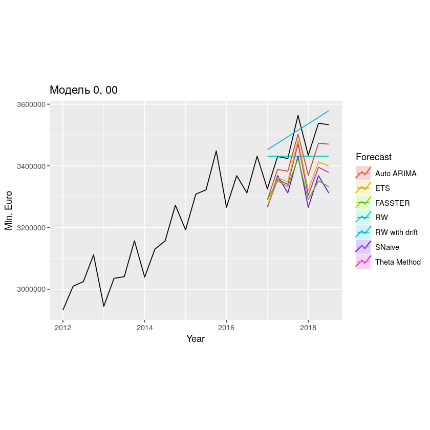

```r
autoplot(window(gdp_agg, start=2012)) +
    autolayer(gdp_rwf, series="RW", PI=FALSE) +
    autolayer(gdp_rwfwd, series="RW with drift", PI=FALSE) +
    autolayer(gdp_snaive, series="SNaive", PI=FALSE) +
    autolayer(gdp_theta, series="Theta Method", PI=FALSE) +
    autolayer(gdp_arima, series="Auto ARIMA", PI=FALSE) +
    autolayer(gdp_ets, series="ETS", PI=FALSE) +
    autolayer(ts(gdp_fasster$value, frequency = 4, start = 2017) , series="FASSTER") +
    xlab("Year") + ylab("Mln. Euro") +
    ggtitle("Модель 0, 00") +
    guides(colour=guide_legend(title="Forecast")) +
    theme(aspect.ratio = 0.75)
```

```r
auto.arima(train)
ets(train)
```

```
Series: train
ARIMA(2,0,1)(0,1,1)[4] with drift

Coefficients:
         ar1      ar2      ma1     sma1      drift
      1.6114  -0.6827  -0.3994  -0.6894  19481.575
s.e.  0.1633   0.1518   0.2059   0.1050   2144.301

sigma^2 estimated as 817681831:  log likelihood=-980.68
AIC=1973.35   AICc=1974.44   BIC=1987.94
```

```
ETS(M,A,M)

Call:
 ets(y = train)

  Smoothing parameters:
    alpha = 0.9962
    beta  = 0.1403
    gamma = 1e-04

  Initial states:
    l = 1603429.4477
    b = 24757.6151
    s = 1.0292 0.993 1.0007 0.9772

  sigma:  0.0107

     AIC     AICc      BIC
2198.517 2200.825 2220.813
```

#### Модель 2: RF

Пара-тройка регрессоров:

- лаг [-1]
- лаг сезонный [-1] для eu/us
- близкие ряды
- прочие?

#### [Ensemble learning for time series forecasting in R](https://petolau.github.io/Ensemble-of-trees-for-forecasting-time-series/)

#### [Forecast double seasonal time series with multiple linear regression in R](https://petolau.github.io/Forecast-double-seasonal-time-series-with-multiple-linear-regression-in-R/)

```r
library(randomForest)
library(data.table)
library(stats)
library(plotly)
library(party)
```

```r
df_eu = read.csv(file="../hm/hts_eu_a10.csv", header=TRUE, sep=",")
```

```r
df_eu = as.data.table(df_eu)
```

```r
df_gdp = read.csv(file="../hm/data/eu_gdp_eu28.csv", header=TRUE, sep=",")
```

```r
DT <- as.data.table(df_gdp)
n_date <- unique(DT[, time])
period <- 4
```

```r
length(n_date)
```

95

```r
library(ggplot2)
```

```r
theme_ts <- theme(panel.border = element_rect(fill = NA,
                                              colour = "grey10"),
                  panel.background = element_blank(),
                  panel.grid.minor = element_line(colour = "grey85"),
                  panel.grid.major = element_line(colour = "grey85"),
                  panel.grid.major.x = element_line(colour = "grey85"),
                  axis.text = element_text(size = 13, face = "bold"),
                  axis.title = element_text(size = 15, face = "bold"),
                  plot.title = element_text(size = 16, face = "bold"),
                  strip.text = element_text(size = 16, face = "bold"),
                  strip.background = element_rect(colour = "black"),
                  legend.text = element_text(size = 15),
                  legend.title = element_text(size = 16, face = "bold"),
                  legend.background = element_rect(fill = "white"),
                  legend.key = element_rect(fill = "white"))
```

```r
data_train <- DT[time %in% n_date[1:88]]
data_test <- DT[time %in% n_date[89:95]]
```

```r
data_test
```

| time | values |
| --- | --- |
| 2017-01-01 | 3325036 |
| 2017-04-01 | 3430170 |
| 2017-07-01 | 3423832 |
| 2017-10-01 | 3563620 |
| 2018-01-01 | 3434383 |
| 2018-04-01 | 3538041 |
| 2018-07-01 | 3533647 |

```r
data_ts <- ts(DT$values, freq = period)
data_ts_train <- data_ts[1:88]
data_ts_test  <- data_ts[89:95]
```

```r
decomp_ts <- stl(data_ts, s.window = "periodic", robust = TRUE)$time.series
decomp_ts_train <- decomp_ts[1:88, ]
decomp_ts_test  <- decomp_ts[89:95, ]
```

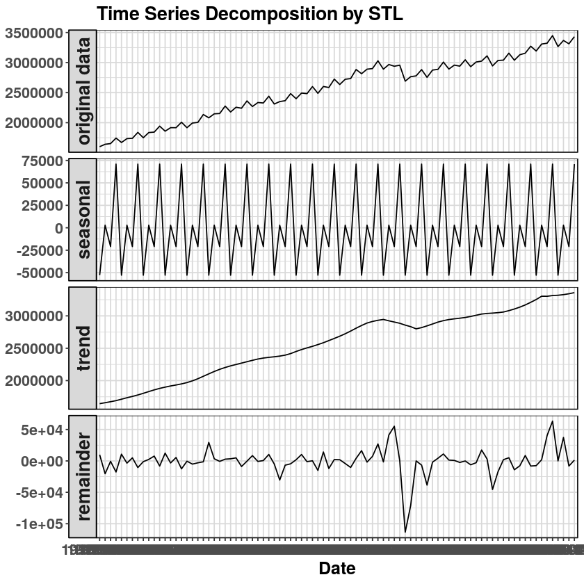

```r
decomp_stl <- data.table(Load = c(data_train$values, as.numeric(decomp_ts_train)),
                         Date = rep(data_train[,time], ncol(decomp_ts_train)+1),
                         Type = factor(rep(c("original data", colnames(decomp_ts_train)),
                                       each = nrow(decomp_ts_train)),
                                       levels = c("original data", colnames(decomp_ts_train))))


ggplot(decomp_stl, aes(x = Date, y = Load, group = 1 )) +
  geom_line() +
  facet_grid(Type ~ ., scales = "free_y", switch = "y") +
  labs(x = "Date", y = NULL,
       title = "Time Series Decomposition by STL") +
  theme_ts
```

#### Constructing features to model

```r
data_msts <- msts(data_ts, seasonal.periods = period)
```

```r
fuur <- fourier(data_msts, K = 2)
```

```r
N <- nrow(data_train)
window <- (N / period) - 1 # number of days in train set minus lag
```

```r
window
```

21

```r
new_load <- rowSums(decomp_ts[, c(1,3)]) # detrended load (seasonal+remainder)
```

```r
lag_seas <- decomp_ts[ , 1] # seasonal part of time series as lag feature
```

```r
matrix_train <- data.table(Load = new_load[1:88],
                           fuur[1:88, ],
                           Lag = lag_seas[1:88])
```

```r
matrix_test <- data.table(Load = new_load[89:95],
                           fuur[89:95, ],
                           Lag = lag_seas[89:95])
```

```r
head(matrix_test)
```

| Load | S1-4 | C1-4 | C2-4 | Lag |
| --- | --- | --- | --- | --- |
| -63509.700 | 1 | 0 | -1 | -52801.727 |
| 11420.203 | 0 | -1 | 1 | 2825.801 |
| -25765.658 | -1 | 0 | -1 | -20916.377 |
| 87375.855 | 0 | 1 | 1 | 70892.313 |
| -68874.963 | 1 | 0 | -1 | -52801.727 |
| 8588.153 | 0 | -1 | 1 | 2825.801 |

#### RPART (CART) tree

In the next two sections, I will describe two regression tree methods. The first is RPART, or CART (Classification and Regression Trees), the second will be CTREE. RPART is recursive partitioning type of binary tree for classification or regression tasks. It performs a search over all possible splits by maximizing an information measure of node impurity, selecting the covariate showing the best split.

```r
library(rpart) # decision tree method
library(rpart.plot) # tree plot
```

```r
tree_1 <- rpart(Load ~ ., data = matrix_train)
```

```r
tree_1$variable.importance
```

**Lag**

203660168000.889

**C1-4**

164411966151.725

**S1-4**

42343746360.6329

**C2-4**

3095544511.46925

```r
tree_1$cptable
```

|  | CP | nsplit | rel error | xerror | xstd |
| --- | --- | --- | --- | --- | --- |
| 1 | 0.66602105 | 0 | 1.0000000 | 1.0193984 | 0.15318501 |
| 2 | 0.16204258 | 1 | 0.3339790 | 0.3497172 | 0.09161100 |
| 3 | 0.01278046 | 2 | 0.1719364 | 0.1889738 | 0.05752064 |
| 4 | 0.01000000 | 3 | 0.1591559 | 0.1846037 | 0.05921485 |

```r
tree_1$cptable[dim(tree_1$cptable)[1], "nsplit"] # Number of splits
```

3

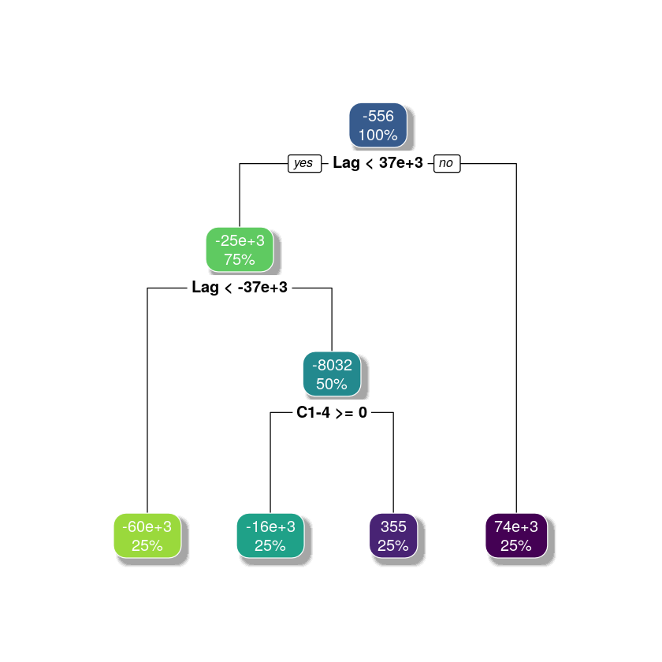

```r
rpart.plot(tree_1, digits = 2,
           box.palette = viridis::viridis(10, option = "D", begin = 0.85, end = 0),
           shadow.col = "grey65", col = "grey99")
```

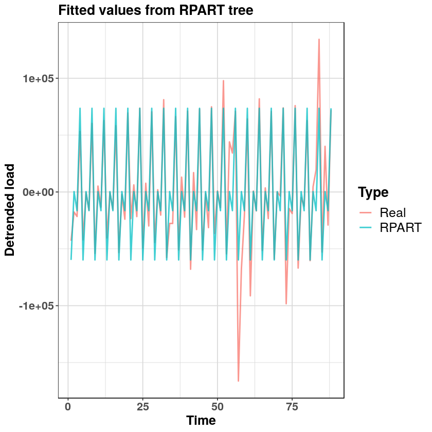

```r
datas <- data.table(Load = c(matrix_train$Load,
                             predict(tree_1)),
                    Time = rep(1:length(matrix_train$Load), 2),
                    Type = rep(c("Real", "RPART"), each = length(matrix_train$Load)))

ggplot(datas, aes(Time, Load, color = Type)) +
  geom_line(size = 0.8, alpha = 0.75) +
  labs(y = "Detrended load", title = "Fitted values from RPART tree") +
  theme_ts
```

The cp is a threshold deciding if each branch fulfills conditions for further processing, so only nodes with fitness larger than factor cp are processed. Other important parameters are the minimum number of observations in needed in a node to split (minsplit) and the maximal depth of a tree (maxdepth). Set the minsplit to 2 and set the maxdepth to its maximal value - 30.

```r
tree_2 <- rpart(Load ~ ., data = matrix_train,
                control = rpart.control(minsplit = 2 ,
                                        maxdepth = 30,
                                        cp = 0.000001))
```

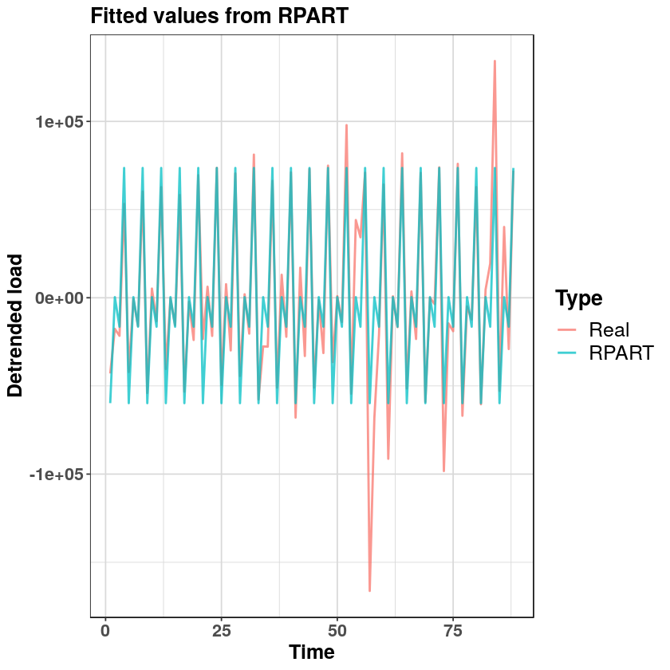

```r
datas <- data.table(Load = c(matrix_train$Load,
                             predict(tree_2)),
                    Time = rep(1:length(matrix_train$Load), 2),
                    Type = rep(c("Real", "RPART"), each = length(matrix_train$Load)))

ggplot(datas, aes(Time, Load, color = Type)) +
  geom_line(size = 0.8, alpha = 0.75) +
  labs(y = "Detrended load", title = "Fitted values from RPART") +
  theme_ts
```

```r
dim(decomp_ts)
```

1. 95

2. 3

```r
matrix_test
```

| Load | S1-4 | C1-4 | C2-4 | Lag |
| --- | --- | --- | --- | --- |
| -63509.700 | 1 | 0 | -1 | -52801.727 |
| 11420.203 | 0 | -1 | 1 | 2825.801 |
| -25765.658 | -1 | 0 | -1 | -20916.377 |
| 87375.855 | 0 | 1 | 1 | 70892.313 |
| -68874.963 | 1 | 0 | -1 | -52801.727 |
| 8588.153 | 0 | -1 | 1 | 2825.801 |
| -22093.010 | -1 | 0 | -1 | -20916.377 |

```r
trend_part <- ts(decomp_ts_train[,2])
trend_fit <- auto.arima(trend_part)
trend_for <- forecast(trend_fit, 7)$mean
```

```r
for_rpart <- predict(tree_2, matrix_test) + trend_for
```

```r
for_rpart
```

```
Time Series:
Start = 89
End = 95
Frequency = 1
      1       2       3       4       5       6       7
3320570 3404171 3411844 3526177 3416253 3498586 3502770
```

```r
predict(tree_2, matrix_test)
```

**1**

-59762.4152073485

**2**

355.472911627721

**3**

-16419.9000322533

**4**

73601.8495853017

**5**

-59762.4152073485

**6**

355.472911627721

**7**

-16419.9000322533

```r
library(ggforce)
```

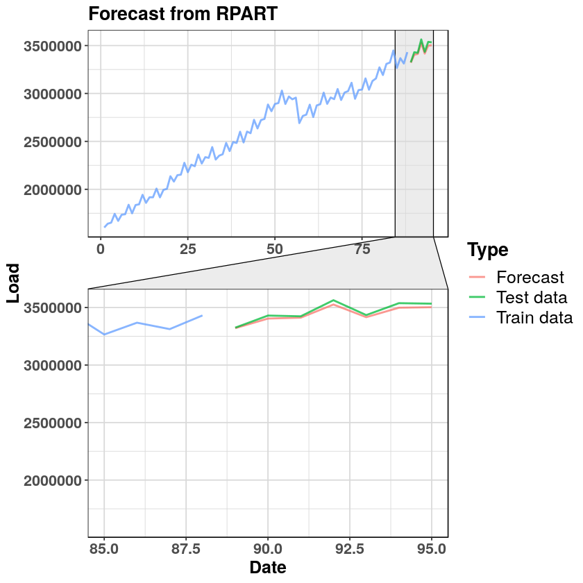

```r
data_for <- data.table(Load = c(data_train$values, data_test$values, for_rpart),
                       Date = c(data_train$time, rep(data_test$time, 2)),
                       Type = c(rep("Train data", nrow(data_train)),
                                rep("Test data", nrow(data_test)),
                                rep("Forecast", nrow(data_test))))

ggplot(data_for, aes(Date, Load, color = Type)) +
  geom_line(size = 0.8, alpha = 0.75) +
  facet_zoom(x = Date[85:95], zoom.size = 1.2) +
  labs(title = "Forecast from RPART") +
  theme_ts
```

```r
ctree_1 <- ctree(Load ~ ., data = matrix_train)
```

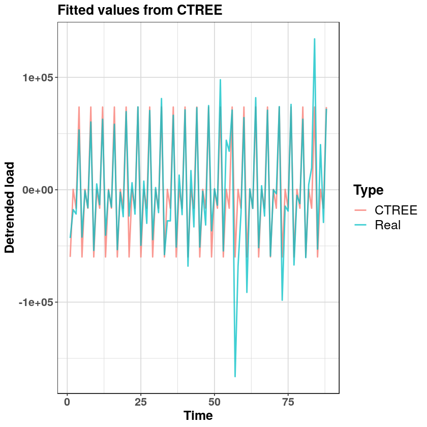

```r
datas <- data.table(Load = c(matrix_train$Load,
                             predict(ctree_1)),
                    Time = rep(1:length(matrix_train$Load), 2),
                    Type = rep(c("Real", "CTREE"), each = length(matrix_train$Load)))

ggplot(datas, aes(Time, Load, color = Type)) +
  geom_line(size = 0.8, alpha = 0.75) +
  labs(y = "Detrended load", title = "Fitted values from CTREE") +
  theme_ts
```

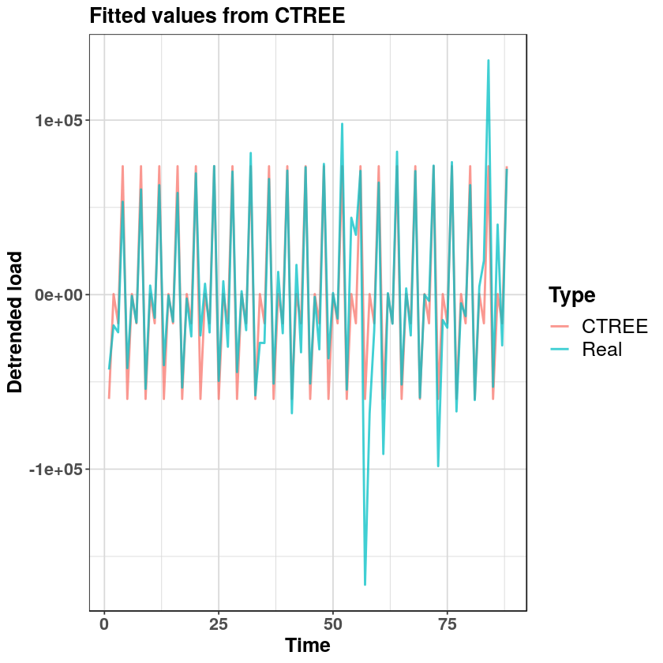

```r
ctree_2 <- ctree(Load ~ ., data = matrix_train,
                        controls = party::ctree_control(teststat = "quad",
                                                        testtype = "Teststatistic",
                                                        mincriterion = 0.925,
                                                        minsplit = 1,
                                                        minbucket = 1))

datas <- data.table(Load = c(matrix_train$Load,
                             predict(ctree_2)),
                    Time = rep(1:length(matrix_train$Load), 2),
                    Type = rep(c("Real", "CTREE"), each = length(matrix_train$Load)))

ggplot(datas, aes(Time, Load, color = Type)) +
  geom_line(size = 0.8, alpha = 0.75) +
  labs(y = "Detrended load", title = "Fitted values from CTREE") +
  theme_ts
```

```r
for_ctree <- predict(ctree_2, matrix_test) + trend_for
```

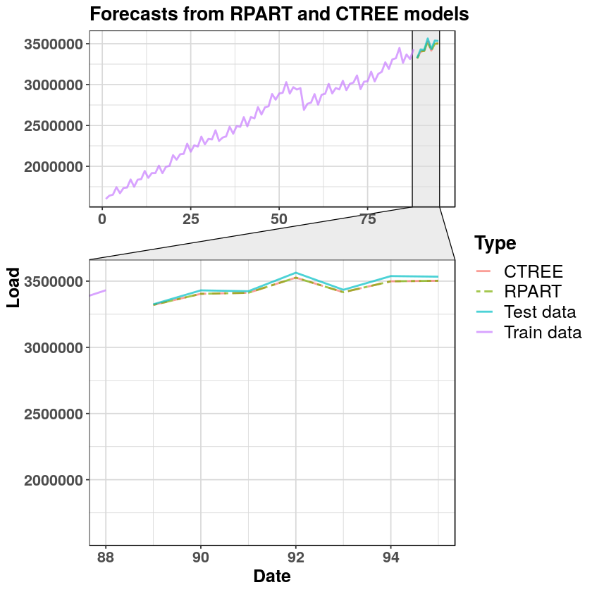

```r
data_for <- data.table(Load = c(data_train$values, data_test$values, for_rpart, for_ctree),
                       Date = c(data_train$time, rep(data_test$time, 3)),
                       Type = c(rep("Train data", nrow(data_train)),
                                rep("Test data", nrow(data_test)),
                                rep("RPART", nrow(data_test)),
                                rep("CTREE", nrow(data_test))))

ggplot(data_for, aes(Date, Load, color = Type, linetype = Type)) +
  geom_line(size = 0.8, alpha = 0.7) +
  facet_zoom(x = Date[88:95], zoom.size = 1.62) +
  labs(title = "Forecasts from RPART and CTREE models") +
  scale_linetype_manual(values = c(5,6,1,1)) +
  theme_ts
```

```r
accuracy(matrix_train$Load, predict(tree_1))
accuracy(matrix_train$Load, predict(tree_2))
accuracy(matrix_train$Load, predict(ctree_1))
accuracy(matrix_train$Load, predict(ctree_2))
```

|  | ME | RMSE | MAE | MPE | MAPE |
| --- | --- | --- | --- | --- | --- |
| Test set | -6.341711e-12 | 20929.81 | 12483.77 | 7.834837e-15 | 928.4881 |

|  | ME | RMSE | MAE | MPE | MAPE |
| --- | --- | --- | --- | --- | --- |
| Test set | -6.341711e-12 | 20929.81 | 12483.77 | 7.834837e-15 | 928.4881 |

|  | ME | RMSE | MAE | MPE | MAPE |
| --- | --- | --- | --- | --- | --- |
| Test set | -9.530577e-12 | 20929.81 | 12483.77 | 4.484199e-14 | 928.4881 |

|  | ME | RMSE | MAE | MPE | MAPE |
| --- | --- | --- | --- | --- | --- |
| Test set | -9.530577e-12 | 20929.81 | 12483.77 | 4.484199e-14 | 928.4881 |

```r
accuracy(data_test$value, for_rpart)
accuracy(data_test$value, for_ctree)
```

|  | ME | RMSE | MAE | MPE | MAPE | ACF1 | Theil's U |
| --- | --- | --- | --- | --- | --- | --- | --- |
| Test set | -24051.12 | 26940 | 24051.12 | -0.6930563 | 0.6930563 | -0.2798248 | 0.3608793 |

|  | ME | RMSE | MAE | MPE | MAPE | ACF1 | Theil's U |
| --- | --- | --- | --- | --- | --- | --- | --- |
| Test set | -24051.12 | 26940 | 24051.12 | -0.6930563 | 0.6930563 | -0.2798248 | 0.3608793 |

## Disaggregated TS

```r
df_eu = read.csv(file="hts_eu_a10.csv", header=TRUE, sep=",")
```

```r
df_eu = as.data.table(df_eu)
```

```r
df_eu_sums = rowSums(df_eu[,2:282])
```

```r
df_gdp_check = df_gdp[21:95,]
```

#### Модель 0: RW with drift

The random walk with drift model is

$$Y_t=c + Y_{t-1} + Z_t$$

`rwf(y, h, drift=TRUE)`

```r
library(hts)
```

```r
data = df_eu
```

```r
head(data)
```

| X0 | BEA | BEB | BEF | BEG | BEJ | BEK | BEL | BEM | BEO | ⋯ | UKB | UKF | UKG | UKJ | UKK | UKL | UKM | UKO | UKR | ZTX |
| --- | --- | --- | --- | --- | --- | --- | --- | --- | --- | --- | --- | --- | --- | --- | --- | --- | --- | --- | --- | --- |
| 2000-01-01 | 698.5 | 12887.5 | 2825.0 | 10591.5 | 2161.0 | 3509 | 5215.0 | 5877.5 | 11166.5 | ⋯ | 76488.40 | 22862.20 | 73151.90 | 23719.95 | 20741.50 | 57761.00 | 37932.55 | 62936.55 | 13489.10 | -16140.567 |
| 2000-04-01 | 749.5 | 13162.0 | 3037.5 | 10809.5 | 2160.5 | 3558 | 5335.0 | 6166.0 | 11481.0 | ⋯ | 75447.70 | 23319.40 | 73312.00 | 24628.50 | 20607.85 | 57974.95 | 39850.10 | 64350.75 | 13577.45 | -2465.033 |
| 2000-07-01 | 786.5 | 12941.0 | 2840.5 | 10664.5 | 2141.0 | 3569 | 5452.5 | 6301.0 | 11073.5 | ⋯ | 75416.75 | 23405.15 | 74807.70 | 25083.70 | 20351.05 | 58053.75 | 41213.95 | 65464.95 | 13748.05 | -10518.533 |
| 2000-10-01 | 781.5 | 13301.0 | 3108.5 | 11425.5 | 2330.5 | 3535 | 5528.0 | 6625.5 | 11661.5 | ⋯ | 79694.75 | 24750.20 | 76852.75 | 25989.25 | 19280.20 | 59448.60 | 42271.75 | 67689.75 | 13551.25 | 26812.517 |
| 2001-01-01 | 771.5 | 13219.5 | 2861.0 | 11164.5 | 2342.5 | 3452 | 5541.0 | 6534.5 | 11485.5 | ⋯ | 73919.55 | 22958.40 | 73992.25 | 24918.60 | 20554.10 | 57599.55 | 40398.35 | 65059.30 | 13200.30 | -18966.600 |
| 2001-04-01 | 745.5 | 13211.0 | 3149.0 | 11561.5 | 2416.5 | 3414 | 5604.5 | 6665.5 | 12023.5 | ⋯ | 73572.15 | 23664.10 | 78670.00 | 25203.90 | 20562.55 | 59190.70 | 42485.00 | 68913.70 | 14585.65 | -2926.000 |

```r
rownames(data) = as.Date(data$X0)
#rownames(data)
data$X0 <- NULL
#colnames(data)
```

```r
dim(data)
```

1. 75

2. 281

```r
y = hts(data, characters = c(2,1))
s = smatrix(y)
```

```r
head(s)gts_train
```

| 1 | 1 | 1 | 1 | 1 | 1 | 1 | 1 | 1 | 1 | ⋯ | 1 | 1 | 1 | 1 | 1 | 1 | 1 | 1 | 1 | 1 |
| --- | --- | --- | --- | --- | --- | --- | --- | --- | --- | --- | --- | --- | --- | --- | --- | --- | --- | --- | --- | --- |
| 1 | 1 | 1 | 1 | 1 | 1 | 1 | 1 | 1 | 1 | ⋯ | 0 | 0 | 0 | 0 | 0 | 0 | 0 | 0 | 0 | 0 |
| 0 | 0 | 0 | 0 | 0 | 0 | 0 | 0 | 0 | 0 | ⋯ | 0 | 0 | 0 | 0 | 0 | 0 | 0 | 0 | 0 | 0 |
| 0 | 0 | 0 | 0 | 0 | 0 | 0 | 0 | 0 | 0 | ⋯ | 0 | 0 | 0 | 0 | 0 | 0 | 0 | 0 | 0 | 0 |
| 0 | 0 | 0 | 0 | 0 | 0 | 0 | 0 | 0 | 0 | ⋯ | 0 | 0 | 0 | 0 | 0 | 0 | 0 | 0 | 0 | 0 |
| 0 | 0 | 0 | 0 | 0 | 0 | 0 | 0 | 0 | 0 | ⋯ | 0 | 0 | 0 | 0 | 0 | 0 | 0 | 0 | 0 | 0 |

```r
gts_train  <- window(y, start=1, end=68)
gts_test  <- window(y, start=69, end=75)
```

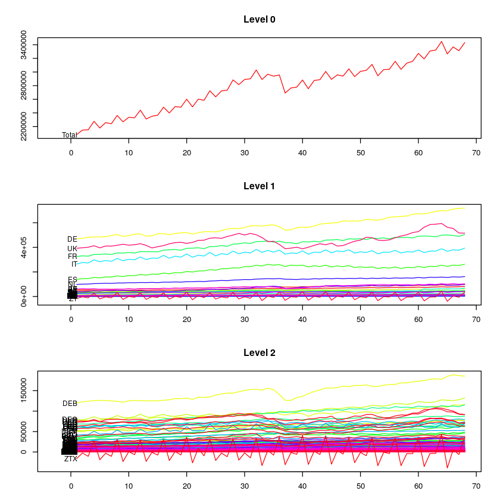

```r
plot(gts_train, levels = c(0, 1, 2))
```

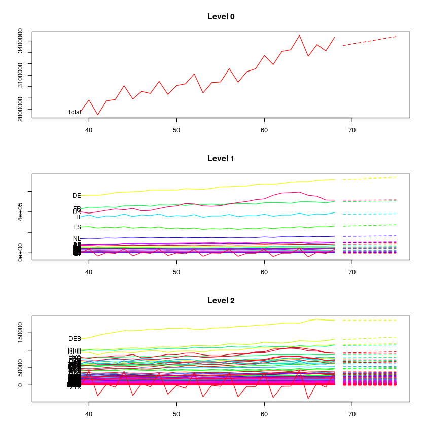

```r
gdpforecast <- forecast(gts_train, h=7, method="bu")

plot(gdpforecast, include=30)
```

```r
accuracy.gts(gdpforecast, gts_test)
```

|  | Total | AT | BE | BG | CY | CZ | DE | DK | EE | EL | ⋯ | UKB | UKF | UKG | UKJ | UKK | UKL | UKM | UKO | UKR | ZTX |
| --- | --- | --- | --- | --- | --- | --- | --- | --- | --- | --- | --- | --- | --- | --- | --- | --- | --- | --- | --- | --- | --- |
| ME | 6.487836e+04 | 1026.0669908 | 1389.1067914 | 492.519228 | 107.296255 | 1896.304962 | 19874.693381 | 225.8231464 | 210.469717 | 755.3348299 | ⋯ | 1345.546922 | 1346.251113 | 2042.8837552 | 447.284892 | -1192.1202029 | 4841.082753 | 2.75265734 | -1738.9821330 | 1340.659655 | -6211.3433669 |
| RMSE | 8.889066e+04 | 1463.0631020 | 1989.9345503 | 873.409315 | 153.142671 | 2515.190124 | 21681.792132 | 685.5533183 | 258.907326 | 1620.0321294 | ⋯ | 2361.446547 | 1396.514734 | 2625.7532999 | 1051.461227 | 1633.9287079 | 5070.330112 | 685.56284521 | 2443.3561439 | 1375.101527 | 22082.0401277 |
| MAE | 7.498475e+04 | 1233.0824580 | 1595.5684896 | 763.876089 | 129.136670 | 2378.695334 | 19874.693381 | 528.8410673 | 221.731659 | 1390.4420474 | ⋯ | 2116.313108 | 1346.251113 | 2106.9292129 | 949.095801 | 1251.7797368 | 4841.082753 | 460.10362209 | 2118.9849599 | 1340.659655 | 16332.7315110 |
| MAPE | 2.139216e+00 | 1.4531645 | 1.5996642 | 6.528354 | 2.934827 | 5.302043 | 2.632525 | 0.8332964 | 4.113043 | 3.4590929 | ⋯ | 2.858287 | 4.187436 | 2.2311211 | 2.771341 | 3.4735705 | 6.835335 | 0.70536516 | 2.3128872 | 6.003355 | 67.9449404 |
| MPE | 1.835268e+00 | 1.1957964 | 1.3851127 | 3.882324 | 2.400202 | 4.074180 | 2.632525 | 0.3499023 | 3.879903 | 1.7746732 | ⋯ | 1.753346 | 4.187436 | 2.1607170 | 1.236362 | -3.3181695 | 6.835335 | -0.01096043 | -1.9065761 | 6.003355 | 66.8888449 |
| MASE | 8.921827e-01 | 0.9294849 | 0.8509902 | 1.685777 | 1.539356 | 1.845530 | 2.796328 | 0.5428274 | 2.149417 | 0.9785633 | ⋯ | 1.076280 | 1.186262 | 0.9222495 | 1.069449 | 0.8102811 | 2.614954 | 0.28220020 | 0.8449964 | 1.884219 | 0.4738912 |

```r
allts <- aggts(gts_train)
```

```r
dim(allts)
```

1. 68

2. 311

```r
allf <- matrix(, nrow=7, ncol=ncol(allts))
```

### RW with drift

```r
# Select preferred time-series forecasting method for each time series

for(i in 1:ncol(allts))
  allf[,i] <- rwf(allts[,i], h=7, drift=TRUE)$mean
allf <- ts(allf)
```

```r
colnames(allf)  <-   colnames(allts)
```

```r
# combine the forecasts with the group matrix to get a gts object
g <- get_nodes(gts_train)
y.f <- combinef(allf, nodes = g)
```

```r
forecasts_7 = y.f[[1]]
```

```r
colnames(forecasts_7) = colnames(y[[1]])
```

```r
data_f5 = rbind(gts_train[[1]], forecasts_7)
```

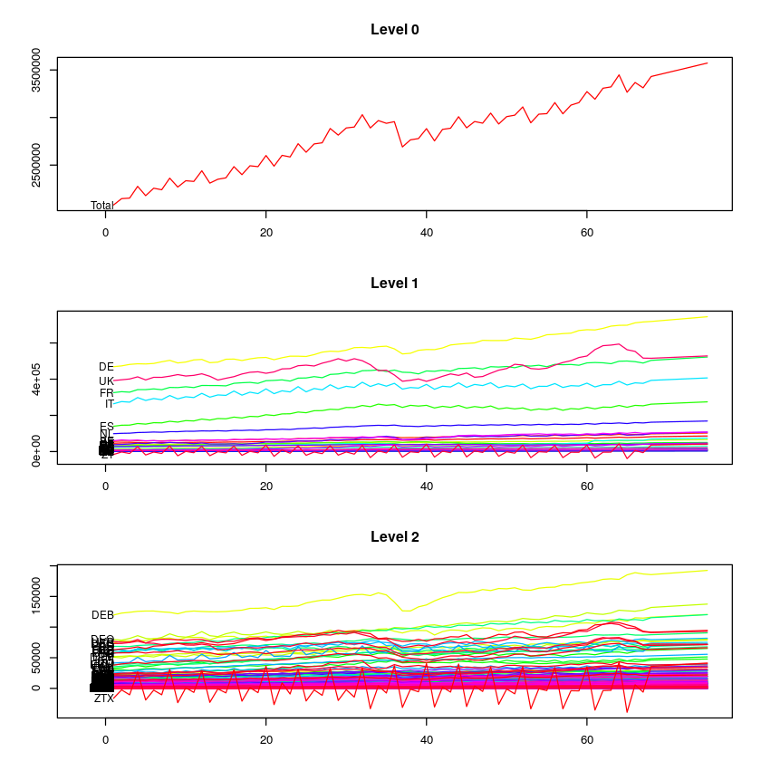

```r
y_f5 = hts(data_f5, characters = c(2,3))

plot(y_f5, levels = c(0, 1, 2))
```

```r
gts_forecasts_7  <- window(y_f5, start=69, end=75)
```

```r
accuracy.gts(gts_forecasts_7, gts_test)
```

|  | Total | AT | BE | BG | CY | CZ | DE | DK | EE | EL | ⋯ | UKB | UKF | UKG | UKJ | UKK | UKL | UKM | UKO | UKR | ZTX |
| --- | --- | --- | --- | --- | --- | --- | --- | --- | --- | --- | --- | --- | --- | --- | --- | --- | --- | --- | --- | --- | --- |
| ME | -47804.571429 | -475.7310235 | -1406.520256 | -225.141151 | 55.729069 | 2009.057640 | 14824.939232 | -846.917058 | 167.958849 | 622.418230 | ⋯ | 1586.176333 | 878.097868 | 965.945096 | -141.3789979 | -2211.251706 | -75.0997868 | 932.871962 | -1174.674947 | 899.591471 | -47823.1407 |
| RMSE | 71937.089305 | 1150.7610563 | 1923.609541 | 714.426753 | 118.980977 | 2698.234093 | 16911.064059 | 1134.665549 | 230.242122 | 1459.836103 | ⋯ | 2536.151831 | 954.433723 | 1654.173448 | 769.7848380 | 2603.476776 | 1069.9818138 | 1301.103055 | 1937.011434 | 1009.214680 | 52234.5334 |
| MAE | 62579.114286 | 917.5448827 | 1635.004264 | 602.071429 | 106.028856 | 2542.940938 | 14824.939232 | 880.569723 | 195.960768 | 1275.250213 | ⋯ | 2305.394670 | 878.097868 | 1315.571748 | 612.7681237 | 2211.251706 | 899.8264392 | 1190.905011 | 1634.135928 | 899.591471 | 47823.1407 |
| MAPE | 1.826455 | 1.1129593 | 1.670034 | 5.471035 | 2.429486 | 5.665155 | 1.959375 | 1.387490 | 3.641841 | 3.179747 | ⋯ | 3.109398 | 2.729106 | 1.395556 | 1.8252981 | 6.089185 | 1.2768190 | 1.787168 | 1.785817 | 4.015585 | 599.8666 |
| MPE | -1.411862 | -0.5971693 | -1.443361 | -2.414915 | 1.209920 | 4.306223 | 1.959375 | -1.334772 | 3.062157 | 1.450681 | ⋯ | 2.078354 | 2.729106 | 1.012123 | -0.4768099 | -6.089185 | -0.1247281 | 1.383024 | -1.294138 | 4.015585 | 594.3838 |

### Snaive

```r
allts <- aggts(gts_train)
```

```r
allf <- matrix(, nrow=7, ncol=ncol(allts))
```

```r
# Select preferred time-series forecasting method for each time series
for(i in 1:ncol(allts))
  allf[,i] <- snaive(msts(allts[,i], seasonal.periods = 4), h=7)$mean
allf <- ts(allf)
```

```r
# forecast(auto.arima(train), h=7)$mean
```

```r
colnames(allf)  <-  colnames(allts)
```

```r
# combine the forecasts with the group matrix to get a gts object
g <- get_nodes(gts_train)
y.f <- combinef(allf, nodes = g)
```

```r
forecasts_7 = y.f[[1]]
```

```r
colnames(forecasts_7) = colnames(y[[1]])
```

```r
data_f5 = rbind(gts_train[[1]], forecasts_7)
```

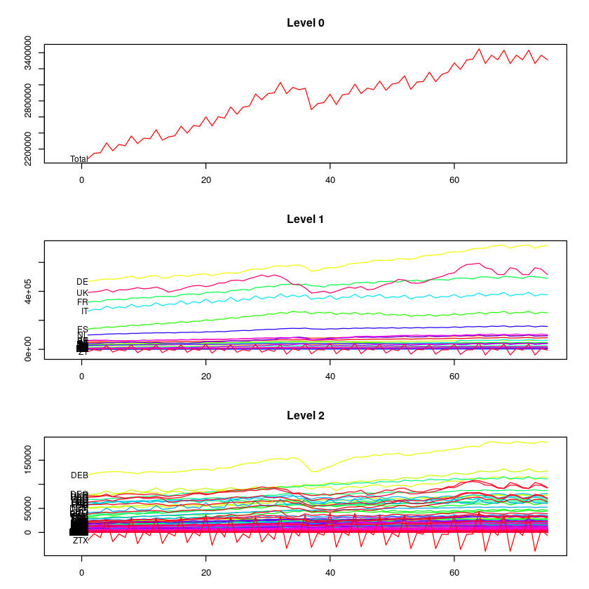

```r
y_f5 = hts(data_f5, characters = c(2,3))

plot(y_f5, levels = c(0, 1, 2))
```

```r
gts_forecasts_7  <- window(y_f5, start=69, end=75)
```

```r
accuracy.gts(gts_forecasts_7, gts_test)
```

|  | Total | AT | BE | BG | CY | CZ | DE | DK | EE | EL | ⋯ | UKB | UKF | UKG | UKJ | UKK | UKL | UKM | UKO | UKR | ZTX |
| --- | --- | --- | --- | --- | --- | --- | --- | --- | --- | --- | --- | --- | --- | --- | --- | --- | --- | --- | --- | --- | --- |
| ME | 1.321581e+05 | 4786.692857 | 4160.857143 | 1132.771429 | 289.038095 | 4904.13810 | 38611.214286 | 2722.871429 | 615.30000 | 1176.507143 | ⋯ | -559.8428571 | -184.600000 | -2199.83571 | 279.250000 | -2460.392857 | -4274.857143 | -539.6500000 | -5806.335714 | 447.185714 | -2699.92857 |
| RMSE | 1.432326e+05 | 5149.190685 | 4330.389186 | 1205.142709 | 307.962707 | 5289.89445 | 40710.956471 | 2858.127652 | 650.73177 | 1266.821347 | ⋯ | 2458.0346653 | 1437.343724 | 4004.77068 | 1386.288153 | 2587.742410 | 5287.373251 | 2930.7978194 | 6999.429452 | 829.691173 | 5884.28683 |
| MAE | 1.321581e+05 | 4786.692857 | 4160.857143 | 1132.771429 | 289.038095 | 4904.13810 | 38611.214286 | 2722.871429 | 615.30000 | 1176.507143 | ⋯ | 2166.2000000 | 1350.185714 | 3538.73571 | 1100.850000 | 2460.392857 | 4369.000000 | 2490.5500000 | 5826.507143 | 694.757143 | 5145.88571 |
| MAPE | 3.791442e+00 | 5.675103 | 4.213287 | 9.842083 | 6.642002 | 10.84929 | 5.129322 | 4.285367 | 11.57169 | 2.940176 | ⋯ | 2.9322957 | 4.205115 | 3.79349 | 3.210907 | 6.705564 | 6.134338 | 3.7689949 | 6.289565 | 3.131973 | 95.53123 |
| MPE | 3.791442e+00 | 5.675103 | 4.213287 | 9.842083 | 6.642002 | 10.84929 | 5.129322 | 4.285367 | 11.57169 | 2.940176 | ⋯ | -0.7639766 | -0.559309 | -2.38510 | 0.745333 | -6.705564 | -6.000639 | -0.8714839 | -6.267566 | 2.013880 | 85.53647 |

### Theta

```r
allts <- aggts(gts_train)
```

```r
allf <- matrix(, nrow=7, ncol=ncol(allts))
```

```r
# Select preferred time-series forecasting method for each time series
for(i in 1:ncol(allts))
  allf[,i] <- thetaf(msts(allts[,i], seasonal.periods = 4), h=7)$mean
allf <- ts(allf)
```

```r
# forecast(auto.arima(train), h=7)$mean
```

```r
colnames(allf)  <-   colnames(allts)
```

```r
# combine the forecasts with the group matrix to get a gts object
g <- get_nodes(gts_train)
y.f <- combinef(allf, nodes = g)
```

```r
forecasts_7 = y.f[[1]]
```

```r
colnames(forecasts_7) = colnames(y[[1]])
```

```r
data_f5 = rbind(gts_train[[1]], forecasts_7)
```

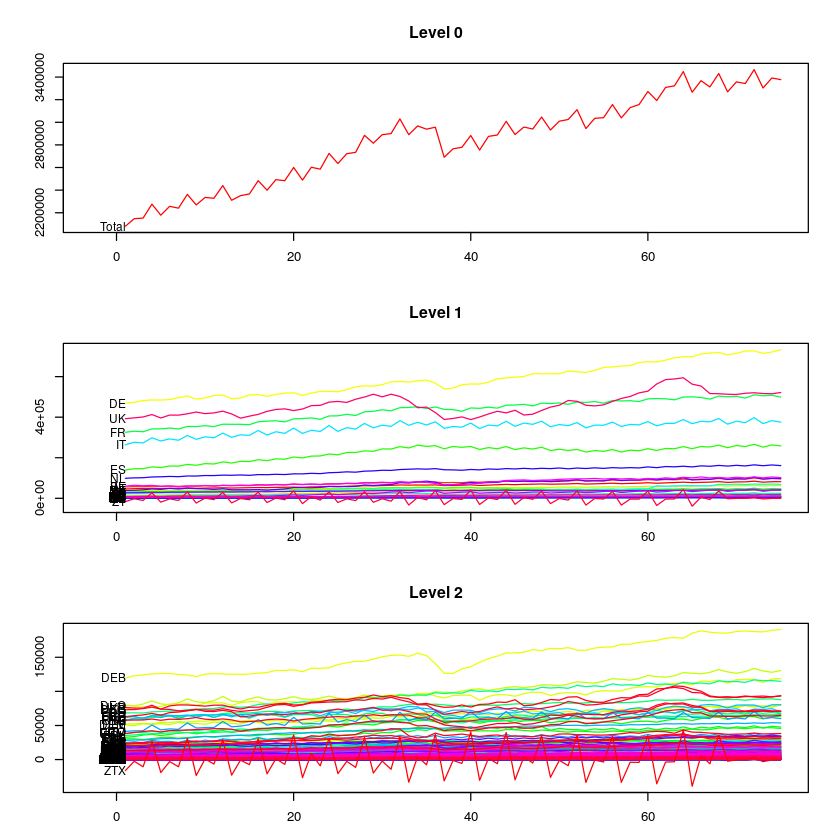

```r
y_f5 = hts(data_f5, characters = c(2,3))

plot(y_f5, levels = c(0, 1, 2))
```

```r
gts_forecasts_7  <- window(y_f5, start=69, end=75)
```

```r
accuracy.gts(gts_forecasts_7, gts_test)
```

|  | Total | AT | BE | BG | CY | CZ | DE | DK | EE | EL | ⋯ | UKB | UKF | UKG | UKJ | UKK | UKL | UKM | UKO | UKR | ZTX |
| --- | --- | --- | --- | --- | --- | --- | --- | --- | --- | --- | --- | --- | --- | --- | --- | --- | --- | --- | --- | --- | --- |
| ME | 1.058988e+05 | 2695.393651 | 2079.607549 | 915.606531 | 538.24778 | 4405.918643 | 28178.642175 | 1399.429778 | 725.90994 | 1831.197567 | ⋯ | 2040.976332 | 1336.779325 | 1298.733211 | 1007.851712 | -792.779264 | 162.2090389 | 2079.948845 | -208.4219963 | 1023.96949 | -8292.92238 |
| RMSE | 1.118594e+05 | 3120.440326 | 2221.000482 | 1166.068552 | 920.06874 | 4700.725328 | 29724.405774 | 1732.037299 | 1032.29377 | 2135.722357 | ⋯ | 2598.845228 | 1472.387328 | 2100.460014 | 1289.785592 | 1647.308677 | 1084.6414493 | 2483.847502 | 1466.9802090 | 1127.48833 | 21164.58468 |
| MAE | 1.058988e+05 | 2695.393651 | 2079.607549 | 1087.860064 | 838.93509 | 4405.918643 | 28178.642175 | 1558.476580 | 956.25635 | 1956.598761 | ⋯ | 2426.993202 | 1336.779325 | 1940.343037 | 1105.545856 | 1378.617689 | 962.0678501 | 2211.174250 | 1195.5861222 | 1023.96949 | 16823.86095 |
| MAPE | 3.041683e+00 | 3.192143 | 2.109921 | 9.610121 | 19.56381 | 9.818589 | 3.742661 | 2.455191 | 18.29083 | 4.907419 | ⋯ | 3.264590 | 4.152164 | 2.073839 | 3.205009 | 3.791897 | 1.3622275 | 3.311559 | 1.3077679 | 4.58027 | 91.96838 |
| MPE | 3.041683e+00 | 3.192143 | 2.109921 | 8.165029 | 12.60973 | 9.818589 | 3.742661 | 2.207692 | 13.97355 | 4.589195 | ⋯ | 2.711211 | 4.152164 | 1.368528 | 2.904106 | -2.255738 | 0.2100201 | 3.106027 | -0.2457358 | 4.58027 | 91.96838 |

### ARIMA

```r
allts <- aggts(gts_train)
```

```r
allf <- matrix(, nrow=7, ncol=ncol(allts))
```

```r
auto_arima_orders  <-   matrix(, nrow=ncol(allts), ncol=6)
```

```r
# Select preferred time-series forecasting method for each time series

for(i in 1:ncol(allts)){
    model  <- auto.arima(msts(allts[,i], seasonal.periods = 4))
    order  <-  model$arma
    auto_arima_orders[i,1]  <- order[1]
    auto_arima_orders[i,2]  <- order[6]
    auto_arima_orders[i,3]  <- order[2]
    auto_arima_orders[i,4]  <- order[3]
    auto_arima_orders[i,5]  <- order[7]
    auto_arima_orders[i,6]  <- order[4]
    allf[,i] <- forecast(model, h=7)$mean
}
allf <- ts(allf)
```

```r
head(auto_arima_orders)
```

| 2 | 0 | 0 | 2 | 1 | 1 |
| --- | --- | --- | --- | --- | --- |
| 1 | 0 | 1 | 0 | 1 | 2 |
| 1 | 0 | 2 | 0 | 1 | 1 |
| 1 | 0 | 0 | 1 | 1 | 0 |
| 2 | 1 | 0 | 1 | 1 | 0 |
| 1 | 0 | 1 | 0 | 1 | 1 |

```r
df_auto_arima_orders  <-  as.data.frame(auto_arima_orders)
```

```r
colnames(df_auto_arima_orders)  <- c('p', 'd', 'q', 'P', 'D', 'Q')
rownames(df_auto_arima_orders)  <- colnames(allts)
```

```r
head(df_auto_arima_orders)
```

|  | p | d | q | P | D | Q |
| --- | --- | --- | --- | --- | --- | --- |
| Total | 2 | 0 | 0 | 2 | 1 | 1 |
| AT | 1 | 0 | 1 | 0 | 1 | 2 |
| BE | 1 | 0 | 2 | 0 | 1 | 1 |
| BG | 1 | 0 | 0 | 1 | 1 | 0 |
| CY | 2 | 1 | 0 | 1 | 1 | 0 |
| CZ | 1 | 0 | 1 | 0 | 1 | 1 |

```r
colnames(allf)  <-   colnames(allts)
```

```r
# combine the forecasts with the group matrix to get a gts object
g <- get_nodes(gts_train)
y.f <- combinef(allf, nodes = g)
```

```r
forecasts_7 = y.f[[1]]
```

```r
colnames(forecasts_7) = colnames(y[[1]])
```

```r
data_f5 = rbind(gts_train[[1]], forecasts_7)
```

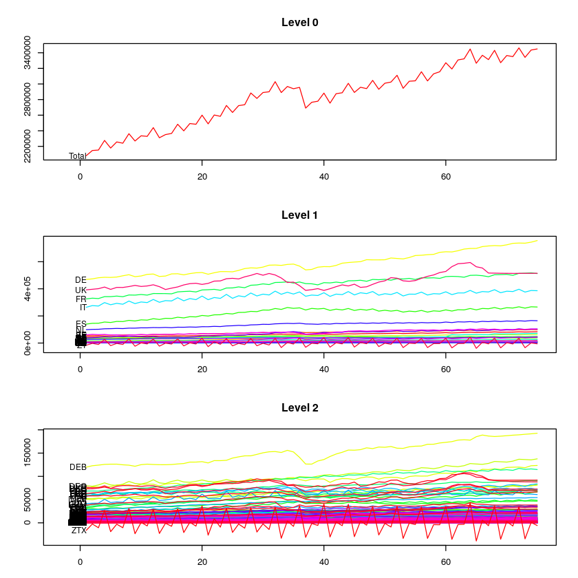

```r
y_f5 = hts(data_f5, characters = c(2,3))

plot(y_f5, levels = c(0, 1, 2))
```

```r
gts_forecasts_7  <- window(y_f5, start=69, end=75)
```

```r
accuracy.gts(gts_forecasts_7, gts_test)
```

|  | Total | AT | BE | BG | CY | CZ | DE | DK | EE | EL | ⋯ | UKB | UKF | UKG | UKJ | UKK | UKL | UKM | UKO | UKR | ZTX |
| --- | --- | --- | --- | --- | --- | --- | --- | --- | --- | --- | --- | --- | --- | --- | --- | --- | --- | --- | --- | --- | --- |
| ME | 81657.333946 | 2378.430692 | 1719.680671 | 1379.57235 | 956.70623 | 3864.976816 | 12809.006995 | 1247.681982 | 1123.81737 | 2956.995938 | ⋯ | 1221.403328 | 2469.395811 | 4494.385219 | 323.2390420 | -1295.203815 | 1091.796209 | 808.946718 | 414.1818991 | 1219.531899 | -2587.11324 |
| RMSE | 83547.346262 | 2541.553036 | 1759.970351 | 1418.95521 | 1001.05231 | 4122.921606 | 13371.969174 | 1407.987240 | 1156.58668 | 3040.832371 | ⋯ | 2288.586934 | 2520.850699 | 4929.365531 | 978.0990078 | 1739.372353 | 1424.957694 | 1205.594461 | 1350.6153748 | 1270.592159 | 3532.11550 |
| MAE | 81657.333946 | 2378.430692 | 1719.680671 | 1379.57235 | 956.70623 | 3864.976816 | 12809.006995 | 1247.681982 | 1123.81737 | 2956.995938 | ⋯ | 2034.287540 | 2469.395811 | 4494.385219 | 888.9311523 | 1353.803245 | 1290.043431 | 1109.035407 | 1116.8219281 | 1219.531899 | 3266.26765 |
| MAPE | 2.348416 | 2.815562 | 1.741564 | 12.00824 | 22.16733 | 8.559735 | 1.701819 | 1.962476 | 21.36697 | 7.417113 | ⋯ | 2.750533 | 7.694279 | 4.785911 | 2.6042593 | 3.753237 | 1.814101 | 1.666553 | 1.2157125 | 5.456307 | 60.03372 |
| MPE | 2.348416 | 2.815562 | 1.741564 | 12.00824 | 22.16733 | 8.559735 | 1.701819 | 1.962476 | 21.36697 | 7.417113 | ⋯ | 1.585213 | 7.694279 | 4.785911 | 0.8739482 | -3.600597 | 1.526635 | 1.196540 | 0.4299837 | 5.456307 | 56.17755 |

#### Модель 3: ARIMAX

- лучшие предикторы - близкие ряды?

##### Выбор самых близких друг к другу рядов

```r
library(dtw)
```

```r
df_eu = read.csv(file="hts_eu_a10.csv", header=TRUE, sep=",")
```

```r
rownames(df_eu) = as.Date(df_eu$X0)
df_eu$X0 <- NULL
```

```r
df_eu  <- df_eu[ , order(names(df_eu))]
```

```r
diss_mat_dtw  <- matrix(, nrow = dim(df_eu)[2], ncol = dim(df_eu)[2])
```

```r
for (i in 1:dim(df_eu)[2]){
    for (j in 1:dim(df_eu)[2]){
        diss_mat_dtw[i,j] = dtw(df_eu[colnames(df_eu)[i]],df_eu[colnames(df_eu)[j]])$distance
    }
}
```

```r
diag(diss_mat_dtw) <- NA
```

```r
closests_dtw <- c()

for (i in 1:dim(df_eu)[2]){
    closests_dtw  <-  c(closests_dtw, which.min(diss_mat_dtw[i,]) )
}
```

```r
names_dtw <- c()

for (i in closests_dtw){
    names_dtw  <-  c(names_dtw, colnames(df_eu)[i])
}
```

```r
names_dtw
```

1. 'CYG'

2. 'ATG'

3. 'BEF'

4. 'BEG'

5. 'DKJ'

6. 'NLR'

7. 'IEO'

8. 'ATL'

9. 'DKO'

10. 'BER'

11. 'LUB'

12. 'ATB'

13. 'PLL'

14. 'ATG'

15. 'NLR'

16. 'DKL'

17. 'PTB'

18. 'CZB'

19. 'SEO'

20. 'ATR'

21. 'HRJ'

22. 'HUM'

23. 'HRF'

24. 'ROJ'

25. 'LTM'

26. 'BGJ'

27. 'EEG'

28. 'SKR'

29. 'LUM'

30. 'LTR'

31. 'MTF'

32. 'SIK'

33. 'EEF'

34. 'PTR'

35. 'CYR'

36. 'MTO'

37. 'MTO'

38. 'MTO'

39. 'IER'

40. 'CYJ'

41. 'CZR'

42. 'BEM'

43. 'SKO'

44. 'ATM'

45. 'LUO'

46. 'SKM'

47. 'LUK'

48. 'SKO'

49. 'FIL'

50. 'LVB'

51. 'ELB'

52. 'DEO'

53. 'DEJ'

54. 'FRO'

55. 'NLG'

56. 'DER'

57. 'DEM'

58. 'DEL'

59. 'DEG'

60. 'FRJ'

61. 'BEA'

62. 'ESJ'

63. 'PTM'

64. 'NLK'

65. 'ATJ'

66. 'CZL'

67. 'FIL'

68. 'PLL'

69. 'ATO'

70. 'BER'

71. 'MTL'

72. 'LVB'

73. 'LVM'

74. 'EEB'

75. 'MTM'

76. 'LVR'

77. 'CYK'

78. 'MTM'

79. 'SKJ'

80. 'MTL'

81. 'PTF'

82. 'DKL'

83. 'IEF'

84. 'ESK'

85. 'ELK'

86. 'ELR'

87. 'SEJ'

88. 'PTK'

89. 'PTO'

90. 'ELK'

91. 'PTB'

92. 'ITL'

93. 'ITF'

94. 'FRL'

95. 'PTG'

96. 'ELG'

97. 'PLG'

98. 'BEO'

99. 'ESB'

100. 'FIO'

101. 'FIK'

102. 'DKB'

103. 'DKF'

104. 'NLJ'

105. 'SIB'

106. 'FIA'

107. 'DKL'

108. 'HUO'

109. 'PTG'

110. 'SIO'

111. 'PTO'

112. 'ITB'

113. 'NLM'

114. 'ITG'

115. 'FRF'

116. 'ITF'

117. 'ESG'

118. 'FRL'

119. 'DEG'

120. 'ITR'

121. 'SIK'

122. 'BER'

123. 'SIF'

124. 'LUG'

125. 'CYL'

126. 'LTL'

127. 'LUL'

128. 'EEO'

129. 'SIO'

130. 'LTJ'

131. 'LTO'

132. 'DKL'

133. 'LTO'

134. 'IEK'

135. 'PTR'

136. 'IER'

137. 'LUG'

138. 'BGB'

139. 'FIM'

140. 'SIL'

141. 'HRL'

142. 'ESL'

143. 'ELF'

144. 'ATL'

145. 'IEM'

146. 'HUG'

147. 'DKF'

148. 'IEJ'

149. 'ATL'

150. 'HUK'

151. 'ESJ'

152. 'FRB'

153. 'FRK'

154. 'DEL'

155. 'BEB'

156. 'FRK'

157. 'ESB'

158. 'DEJ'

159. 'FRL'

160. 'FRR'

161. 'SIR'

162. 'LUO'

163. 'BGM'

164. 'BGB'

165. 'HRR'

166. 'EEK'

167. 'EEL'

168. 'SKR'

169. 'HUJ'

170. 'CYJ'

171. 'MTA'

172. 'BEA'

173. 'SIL'

174. 'HUL'

175. 'SIF'

176. 'CZL'

177. 'HRL'

178. 'SKL'

179. 'LTB'

180. 'LTR'

181. 'CYJ'

182. 'LUL'

183. 'EEF'

184. 'HUJ'

185. 'HRR'

186. 'LTK'

187. 'LTM'

188. 'EEM'

189. 'LVB'

190. 'EEK'

191. 'LUA'

192. 'SIR'

193. 'MTL'

194. 'LTL'

195. 'MTK'

196. 'MTJ'

197. 'EER'

198. 'EEJ'

199. 'CYL'

200. 'MTM'

201. 'ATK'

202. 'FRJ'

203. 'FIG'

204. 'DEJ'

205. 'BEL'

206. 'DKG'

207. 'DKB'

208. 'FRF'

209. 'NLG'

210. 'BEJ'

211. 'LUK'

212. 'PLG'

213. 'PLM'

214. 'ESL'

215. 'SKG'

216. 'FIM'

217. 'BEF'

218. 'ATM'

219. 'BEM'

220. 'LUO'

221. 'ATA'

222. 'BEL'

223. 'ELA'

224. 'FIO'

225. 'HRO'

226. 'ELM'

227. 'DKM'

228. 'ATJ'

229. 'NLJ'

230. 'CYG'

231. 'HRO'

232. 'IEJ'

233. 'CZF'

234. 'IEJ'

235. 'LTB'

236. 'LUM'

237. 'LTG'

238. 'ROJ'

239. 'SKB'

240. 'LUM'

241. 'FIK'

242. 'ITK'

243. 'FIL'

244. 'BEG'

245. 'DKL'

246. 'BEJ'

247. 'BEL'

248. 'CZB'

249. 'BEO'

250. 'ATJ'

251. 'SIR'

252. 'ATR'

253. 'HRF'

254. 'HUL'

255. 'MTO'

256. 'CYM'

257. 'HUR'

258. 'LVB'

259. 'FIR'

260. 'SIA'

261. 'LTL'

262. 'IEK'

263. 'SKM'

264. 'CZL'

265. 'EEO'

266. 'SKR'

267. 'LUM'

268. 'LUM'

269. 'BGB'

270. 'LTM'

271. 'ATK'

272. 'ITB'

273. 'UKJ'

274. 'UKO'

275. 'UKF'

276. 'NLG'

277. 'FRB'

278. 'FRL'

279. 'UKG'

280. 'SEO'

281. 'PTA'

```r
length(names_dtw)
```

281

```r
names_dtw_1  <-  c(rep(NA, 30), names_dtw)
```

```r
library(TSA)
```

```r
allts <- aggts(gts_train)
```

```r
allf <- matrix(, nrow=7, ncol=ncol(allts))
```

```r
head(df_auto_arima_orders)
```

[output not shown]

```r
df_auto_arima_orders[31,]
```

|  | p | d | q | P | D | Q |
| --- | --- | --- | --- | --- | --- | --- |
| ATA | 1 | 0 | 0 | 2 | 1 | 1 |

```r
# Select preferred time-series forecasting method for each time series

for(i in 1:30){
    model  <- auto.arima(msts(allts[,i], seasonal.periods = 4))
    allf[,i] <- forecast(model, h=7)$mean
}

for(i in 31:ncol(allts)){
    model  <- arimax(msts(allts[,i], seasonal.periods = 4), order = c(df_auto_arima_orders[i,1], df_auto_arima_orders[i,2], df_auto_arima_orders[i,3]), seasonal = list(order = c(df_auto_arima_orders[i,4], df_auto_arima_orders[i,5], df_auto_arima_orders[i,6]), period = 4),
 xreg = allts[,names_dtw_1[i]],  method="ML")

    a  <-  gts_test[[1]][,names_dtw_1[i]]

    allf[,i] <- predict(model, n.ahead=7, newxreg = a)$pred

}
```

```r
allf <- ts(allf)
```

```r
allf
```

| Total | AT | BE | BG | CY | CZ | DE | DK | EE | EL | ⋯ | UKB | UKF | UKG | UKJ | UKK | UKL | UKM | UKO | UKR | ZTX |
| --- | --- | --- | --- | --- | --- | --- | --- | --- | --- | --- | --- | --- | --- | --- | --- | --- | --- | --- | --- | --- |
| 3272099 | 80456.28 | 95259.28 | 9955.088 | 4097.709 | 39138.17 | 718118.9 | 61829.48 | 4826.767 | 36410.09 | ⋯ | 72543.46 | 30602.66 | 90973.34 | 34363.32 | 37991.71 | 69717.70 | 63975.14 | 92672.56 | 21094.46 | -34899.050 |
| 3363922 | 81274.33 | 97759.34 | 10748.890 | 4300.401 | 41191.23 | 725810.9 | 63311.58 | 5061.180 | 38203.08 | ⋯ | 72850.62 | 31066.38 | 91606.35 | 34302.68 | 38997.72 | 69570.67 | 64412.10 | 93449.73 | 21231.27 | 3474.608 |
| 3349263 | 82012.72 | 96269.04 | 11369.206 | 4361.790 | 41615.49 | 737206.5 | 62687.41 | 5096.351 | 39192.42 | ⋯ | 72453.89 | 29431.40 | 89012.56 | 33820.52 | 39102.13 | 69512.10 | 64674.14 | 91438.64 | 21565.32 | -6072.279 |
| 3461087 | 84032.37 | 99764.46 | 11565.687 | 4389.858 | 42347.55 | 739220.1 | 63935.91 | 5224.112 | 37936.47 | ⋯ | 72968.03 | 31639.81 | 90900.51 | 34226.46 | 39221.29 | 69486.69 | 65247.32 | 92500.07 | 21527.71 | 35491.196 |
| 3340255 | 82113.40 | 97577.06 | 10462.850 | 4318.117 | 40618.41 | 737807.7 | 62897.14 | 5126.821 | 35797.21 | ⋯ | 73115.48 | 31292.37 | 90936.46 | 34330.67 | 39118.23 | 69476.32 | 65260.87 | 92613.84 | 20929.31 | -34017.898 |
| 3434044 | 83181.16 | 100053.25 | 11168.728 | 4520.639 | 42671.13 | 745499.8 | 64808.33 | 5314.973 | 37590.19 | ⋯ | 73314.86 | 31390.68 | 91364.78 | 34398.31 | 40463.73 | 69473.64 | 65407.97 | 95076.54 | 20765.75 | 1440.958 |
| 3448805 | 83973.68 | 98572.20 | 11905.526 | 4589.837 | 43095.09 | 756895.4 | 64184.42 | 5315.834 | 38579.53 | ⋯ | 72510.78 | 31313.29 | 90987.01 | 34396.99 | 39952.78 | 69472.74 | 65414.26 | 95565.00 | 20615.34 | -5546.103 |

```r
colnames(allf)  <-   colnames(allts)
```

```r
# combine the forecasts with the group matrix to get a gts object
g <- get_nodes(gts_train)
y.f <- combinef(allf, nodes = g,
keep = "gts", algorithms = "lu")
```

```r
forecasts_7 = y.f[[1]]
```

```r
colnames(forecasts_7) = colnames(y[[1]])
```

```r
data_f5 = rbind(gts_train[[1]], forecasts_7)
```

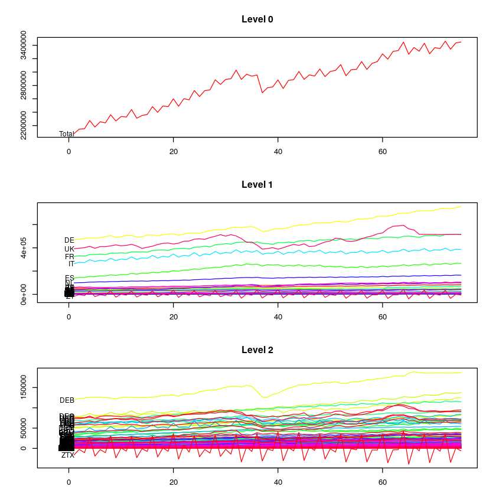

```r
y_f5 = hts(data_f5, characters = c(2,3))

plot(y_f5, levels = c(0, 1, 2))
```

```r
gts_forecasts_7  <- window(y_f5, start=69, end=75)
```

```r
accuracy.gts(gts_forecasts_7, gts_test)
```

|  | Total | AT | BE | BG | CY | CZ | DE | DK | EE | EL | ⋯ | UKB | UKF | UKG | UKJ | UKK | UKL | UKM | UKO | UKR | ZTX |
| --- | --- | --- | --- | --- | --- | --- | --- | --- | --- | --- | --- | --- | --- | --- | --- | --- | --- | --- | --- | --- | --- |
| ME | 81627.482399 | 2358.268370 | 1755.822458 | 1419.20432 | 981.44029 | 3868.069630 | 12945.838644 | 1234.900200 | 1154.10719 | 2997.112772 | ⋯ | 1540.526218 | 1650.436337 | 2973.027059 | 325.9481827 | -1710.727075 | 1778.541206 | 1716.221468 | -603.7111268 | 1726.584288 | -2548.05053 |
| RMSE | 83516.597308 | 2516.936466 | 1796.286479 | 1457.71036 | 1025.26838 | 4121.572570 | 13531.230115 | 1402.307195 | 1186.68059 | 3080.104577 | ⋯ | 2474.586894 | 1678.064717 | 3338.842925 | 1141.6184619 | 2219.665983 | 2062.700788 | 2214.660895 | 1484.5287809 | 1836.846994 | 3498.66033 |
| MAE | 81627.482399 | 2358.268370 | 1755.822458 | 1419.20432 | 981.44029 | 3868.069630 | 12945.838644 | 1234.900200 | 1154.10719 | 2997.112772 | ⋯ | 2295.750419 | 1650.436337 | 2973.027059 | 1060.6671184 | 1747.860080 | 1919.681561 | 1937.086338 | 1233.3227532 | 1726.584288 | 3234.26398 |
| MAPE | 2.347558 | 2.791981 | 1.778041 | 12.35681 | 22.73743 | 8.568496 | 1.719792 | 1.942422 | 21.93772 | 7.518711 | ⋯ | 3.100935 | 5.149762 | 3.163156 | 3.1104657 | 4.836816 | 2.700748 | 2.897309 | 1.3424037 | 7.739449 | 59.43921 |
| MPE | 2.347558 | 2.791981 | 1.778041 | 12.35681 | 22.73743 | 8.568496 | 1.719792 | 1.942422 | 21.93772 | 7.518711 | ⋯ | 2.018274 | 5.149762 | 3.163156 | 0.8685776 | -4.738905 | 2.496089 | 2.551380 | -0.6678593 | 7.739449 | 55.58554 |

#### Модель 4: bvarr/BMR

- bvarr, bvarrKK, bvar_om
- [BMR: documantation](https://www.kthohr.com/bmr.html), pdf
- https://github.com/joergrieger/bvar
- [bvarsv](https://cran.r-project.org/web/packages/bvarsv/bvarsv.pdf)
- [MSBVAR: Markov-switching Bayesian VAR](https://cran.r-project.org/package=MSBVAR)

#### Модель 5: VAR

R: there is a package called "vars" which deals with VAR models.

Python: PyFlux has support for VARs and Bayesian VARs.

К недостаткам VAR-моделей можно отнести неопределённость в выборе подходящей длины лага, значительное число оцениваемых параметров и то, что все переменные в модели должны быть стационарными.

- All variables have to be of the same order of integration.
- All the variables are I(0) (stationary): this is in the standard case, i.e. a VAR in level
- All the variables are I(d) (non-stationary) with d > 0:
  - The variables are cointegrated: the error correction term has to be included in the VAR. The model becomes a **Vector error correction model (VECM)** which can be seen as a restricted VAR.
  - The variables are not cointegrated: the variables have first to be differenced d times and one has a VAR in difference.

To use VAR model for non-stationary series, you have to test the cointegration If there is cointegration you use the model VECM Otherwise a VAR on the first differences of the variables

Because of the parameter identification problem, ordinary least squares estimation of the structural VAR would yield inconsistent parameter estimates. This problem can be overcome by rewriting the VAR in reduced form.

- ADL
- Parameter identification problem
- Structural vs. reduced form
- Granger causality, impulse responses, and forecast error variance decompositions